# Week 3 Skill Builders

### 7H2 – Islands in the stream

We just need a function to compute the entropy as

$$H(p) = −\Sigma_i p_i log(p_i)$$

where $p$ is a vector of probabilities summing to 1.

Here’s a function:

```r
H <- function(p) -sum(p*log(p))
```

Let’s first make a list() of the distributions.

```r
IB <- list()
IB[[1]] <- c( 0.2 , 0.2 , 0.2 , 0.2 , 0.2 )
IB[[2]] <- c( 0.8 , 0.1 , 0.05 , 0.025 , 0.025 )
IB[[3]] <- c( 0.05 , 0.15 , 0.7 , 0.05 , 0.05 )
```

Now we use `sapply()` to calculate the `H` values for each item in the list.

```r
sapply( IB , H )
```

```
## [1] 1.6094379 0.7430039 0.9836003
```

[1] 1.6094379 0.7430039 0.9836003

Entropy measures the evenness, the lack of surprise, and of information, in a distribution.

- What are the largest to smallest entropies? Island 1: 1.6094 (highest entropy, most even distribution), Island 3: 0.9836, Island 2: 0.7430 (lowest entropy, most concentrated distribution)
- How surprised would you have been to see birbs in the distribution on each island? Island 1: With an even distribution (0.2 probability for each species), observing any bird species is equally likely, making it the least surprising. The high entropy reflects this balance. Island 2: With one dominant species (0.8 probability) and very low probabilities for others, observing the dominant species would be expected, while seeing other species would be more surprising. The low entropy reflects this skewed distribution. Island 3: With a somewhat dominant species (0.7 probability) and smaller probabilities for the rest, observing the main species would be expected, while seeing other species would be moderately surprising. This intermediate entropy reflects some concentration but not as extreme as Island 2 Since there are differences, we should get right to the KL divergence measure.

```r
DKL <- function(p,q) sum( p*(log(p)-log(q)) )
```

- What does this measure? Hint: distance? The KL divergence function measures the “information distance” or relative entropy between two probability distributions. It quantifies the inefficiency or “cost” of assuming distribution q (the model) when the true distribution is p. A higher KL divergence indicates that using q to approximate p would result in greater information loss.
- What is p, what is q? In this context, p represents the true probability distribution of bird species on an island (e.g., the actual distribution observed). q is the assumed or model distribution, potentially representing another island’s bird species distribution. The function calculates how well the distribution on one island serves as a model for the distribution on another. Let’s let p be true and use q as the model in the different ordered pairings below using the newly minted `DKL()` function

```r
Dm <- matrix( NA , nrow=3 , ncol=3 )
for ( i in 1:3 ) for ( j in 1:3 ) Dm[i,j] <- DKL( IB[[j]] , IB[[i]] )
round( Dm , 2 )
```

```
##      [,1] [,2] [,3]
## [1,] 0.00 0.87 0.63
## [2,] 0.97 0.00 1.84
## [3,] 0.64 2.01 0.00
```

The way to read this is that each row is a model and each column is a true distribution.

- Island the first. Comment on the information distances to the other islands. Island 1 has smaller distances to the other islands. This is because its distribution is more even (higher entropy), meaning it doesn’t assume any bird species to be overly dominant. This lack of specialization makes it more adaptable, so it’s less “surprised” when encountering the distributions of other islands.
- Island the second, and so on. Island 2, with a highly uneven distribution (one species is very common while others are rare), has higher information distances to other islands. It is highly specialized, so it is more “surprised” by the distributions on Islands 1 and 3, which have greater diversity among species. Island 3 Island 3 falls in between, with a moderately skewed distribution (one common species, but others are present). This results in moderate distances to the other islands: it has a lower distance to Island 1 (0.63) and a higher distance to Island 2 (2.01).

*Hint:* An Island with ong distances to the other islands, is it more or less surprised by the other islands?

### 7H5 – Foxes revisited

Here’s the DAG for the model from the previous chapter.

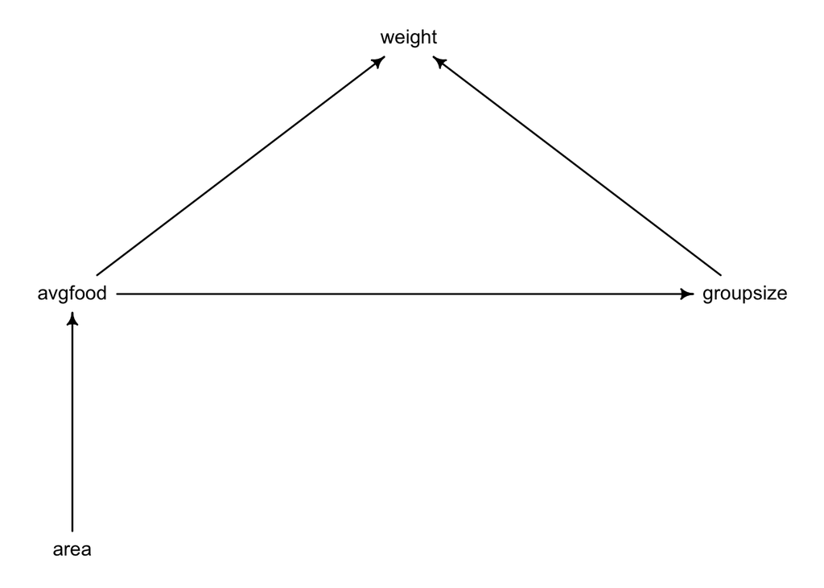

```r
library(dagitty)
dag_6H3 <- dagitty("dag{
  avgfood -> weight <- groupsize
  avgfood -> groupsize
  area -> avgfood
  }"
)
coordinates(dag_6H3) <- list(
  x=c(avgfood=0,groupsize=2,weight=1,area=0),
  y=c(avgfood=1,groupsize=1,weight=0,area=2)
  )
drawdag(dag_6H3)
```

These are the models for outcome weight with predictors

1. avgfood + groupsize + area
2. avgfood + groupsize
3. groupsize + area
4. avgfood
5. area

```r
library(rethinking)
data(foxes)
d <- foxes
d$W <- standardize(d$weight)
d$A <- standardize(d$area)
d$F <- standardize(d$avgfood)
d$G <- standardize(d$groupsize)
m1 <- quap(
alist(
W ~ dnorm( mu , sigma ),
mu <- a + bF*F + bG*G + bA*A,
a ~ dnorm(0,0.2),
c(bF,bG,bA) ~ dnorm(0,0.5),
sigma ~ dexp(1)
), data=d )
m2 <- quap(
alist(
W ~ dnorm( mu , sigma ),
mu <- a + bF*F + bG*G,
a ~ dnorm(0,0.2),
c(bF,bG) ~ dnorm(0,0.5),
sigma ~ dexp(1)
), data=d )
m3 <- quap(
alist(
W ~ dnorm( mu , sigma ),
mu <- a + bG*G + bA*A,
a ~ dnorm(0,0.2),
c(bG,bA) ~ dnorm(0,0.5),
sigma ~ dexp(1)
), data=d )
m4 <- quap(
alist(
W ~ dnorm( mu , sigma ),
mu <- a + bF*F,
a ~ dnorm(0,0.2),
bF ~ dnorm(0,0.5),
sigma ~ dexp(1)
), data=d )
m5 <- quap(
alist(
W ~ dnorm( mu , sigma ),
mu <- a + bA*A,
a ~ dnorm(0,0.2),
bA ~ dnorm(0,0.5),
sigma ~ dexp(1)
), data=d )
```

Compare using WAIC:

```r
compare( m1 , m2 , m3 , m4 , m5 )
```

```
##        WAIC       SE      dWAIC      dSE    pWAIC      weight
## m1 323.2979 16.36574  0.0000000       NA 4.865593 0.373296435
## m2 323.5301 16.04771  0.2322873 3.465753 3.513056 0.332363474
## m3 323.8021 15.81681  0.5042373 3.066488 3.688630 0.290108263
## m4 333.4640 13.75916 10.1661689 7.242558 2.422830 0.002314719
## m5 333.8410 13.76362 10.5431092 7.297235 2.707435 0.001917109
```

```r
#coeftab( remaining models )
coeftab(m4,m5)
```

```
##       m4      m5
## a           0       0
## bF      -0.02      NA
## sigma    0.99    0.99
## bA         NA    0.02
## nobs      116     116
```